# Specific Model Comparisons

Justin Dainer-Best

2017

# Determining optimal parameters of the Self Referent Encoding Task: A large-scale examination of self-referent cognition and depression

This file is one of a series of supplemental explanatory documents for the study “Determining optimal parameters of the Self Referent Encoding Task: A large-scale examination of self-referent cognition and depression”. Data and code are located at [doi: 10.18738/T8/XK5PXX](https://doi.org/10.18738/T8/XK5PXX), and websites with visual R Markdown explanations are located and navigable on the [paper’s github pages website](https://jdbest.github.io/sretmodels/).

## Data description

This file makes smaller models created in `MASS` using MASS::glm.nb() to model the depressive symptom severity as a negative binomial distribution. It makes specific comparisons between variables using `beset` function beset::r2d() to compare them by R<sup>2</sup><sub>D</sub>.

If you are viewing this as an HTML file, and wish to see the code, please download the R Markdown file from the [Texas Data Repository](https://doi.org/10.18738/T8/XK5PXX).

# Comparing specific models

Based on trends highlighted in the plots of the models, we ran small, specific comparisons within each sample. For example, we hypothesized that endorsements of positive and negative word alone were substantially better at predicting depression symptoms than so-called negative/positive processing biases (e.g., the ratio of the number of negative words endorsed to the total number of words endorsed).

We tested this with R<sup>2</sup><sub>D</sub> for each sample, and for each model.

## Endorsement models

### College Students

```
For the model with variables num.neg.endorsed and num.pos.endorsed:
Model-fit R-squared = 0.42
Cross-validated R-squared = 0.42, 95% CI [0.4, 0.43]
```

```
For the model with only num.pos.endorsed:
Model-fit R-squared = 0.27
Cross-validated R-squared = 0.26, 95% CI [0.24, 0.28]
```

```
For the model with only num.neg.endorsed:
Model-fit R-squared = 0.36
Cross-validated R-squared = 0.36, 95% CI [0.34, 0.37]
```

### MTurk sample

```
For the model with variables num.neg.endorsed and num.pos.endorsed:
Model-fit R-squared = 0.36
Cross-validated R-squared = 0.35, 95% CI [0.33, 0.37]
```

```
For the model with only num.pos.endorsed:
Model-fit R-squared = 0.26
Cross-validated R-squared = 0.25, 95% CI [0.23, 0.27]
```

```
For the model with only num.neg.endorsed:
Model-fit R-squared = 0.33
Cross-validated R-squared = 0.32, 95% CI [0.31, 0.34]
```

### Adolescents

```
For the model with variables num.neg.endorsed and num.pos.endorsed:
Model-fit R-squared = 0.33
Cross-validated R-squared = 0.31, 95% CI [0.29, 0.33]
```

```
For the model with only num.pos.endorsed:
Model-fit R-squared = 0.2
Cross-validated R-squared = 0.19, 95% CI [0.16, 0.21]
```

```
For the model with only num.neg.endorsed:
Model-fit R-squared = 0.27
Cross-validated R-squared = 0.26, 95% CI [0.23, 0.28]
```

## Drift Rate models

### College Students

```
For the model with variables v.negative and v.positive:
Model-fit R-squared = 0.41
Cross-validated R-squared = 0.4, 95% CI [0.38, 0.42]
```

```
For the model with only v.positive:
Model-fit R-squared = 0.33
Cross-validated R-squared = 0.33, 95% CI [0.31, 0.35]
```

```
For the model with only v.negative:
Model-fit R-squared = 0.38
Cross-validated R-squared = 0.37, 95% CI [0.35, 0.39]
```

### MTurk sample

```
For the model with variables v.negative and v.positive:
Model-fit R-squared = 0.4
Cross-validated R-squared = 0.39, 95% CI [0.37, 0.41]
```

```
For the model with only v.positive:
Model-fit R-squared = 0.33
Cross-validated R-squared = 0.32, 95% CI [0.3, 0.34]
```

```
For the model with only v.negative:
Model-fit R-squared = 0.38
Cross-validated R-squared = 0.38, 95% CI [0.35, 0.4]
```

### Adolescents

```
For the model with variables v.negative and v.positive:
Model-fit R-squared = 0.36
Cross-validated R-squared = 0.34, 95% CI [0.29, 0.37]
```

```
For the model with only v.positive:
Model-fit R-squared = 0.27
Cross-validated R-squared = 0.26, 95% CI [0.21, 0.29]
```

```
For the model with only v.negative:
Model-fit R-squared = 0.29
Cross-validated R-squared = 0.28, 95% CI [0.24, 0.31]
```

## Self-referential recall models

### College Students

```
For the model with variables numSRposrecalled and numSRnegrecalled:
Model-fit R-squared = 0.36
Cross-validated R-squared = 0.35, 95% CI [0.33, 0.36]
```

```
For the model with only numSRposrecalled:
Model-fit R-squared = 0.13
Cross-validated R-squared = 0.12, 95% CI [0.1, 0.13]
```

```
For the model with only numSRnegrecalled:
Model-fit R-squared = 0.31
Cross-validated R-squared = 0.3, 95% CI [0.28, 0.32]
```

### MTurk Sample

```
For the model with variables numSRposrecalled and numSRnegrecalled:
Model-fit R-squared = 0.28
Cross-validated R-squared = 0.27, 95% CI [0.25, 0.29]
```

```
For the model with only numSRposrecalled:
Model-fit R-squared = 0.08
Cross-validated R-squared = 0.07, 95% CI [0.04, 0.09]
```

```
For the model with only numSRnegrecalled:
Model-fit R-squared = 0.23
Cross-validated R-squared = 0.22, 95% CI [0.2, 0.24]
```

### Adolescents

```
For the model with variables numSRposrecalled and numSRnegrecalled:
Model-fit R-squared = 0.19
Cross-validated R-squared = 0.16, 95% CI [0.14, 0.18]
```

```
For the model with only numSRposrecalled:
Model-fit R-squared = 0.06
Cross-validated R-squared = 0.04, 95% CI [0.02, 0.06]
```

```
For the model with only numSRnegrecalled:
Model-fit R-squared = 0.16
Cross-validated R-squared = 0.14, 95% CI [0.12, 0.16]
```

## Recall models

### College Students

```
For the model with variables numposrecalled and numnegrecalled:
Model-fit R-squared = 0.08
Cross-validated R-squared = 0.07, 95% CI [0.05, 0.08]
```

```
For the model with only numposrecalled:
Model-fit R-squared = 0
Cross-validated R-squared = -0.01, 95% CI [-0.01, -0.01]
```

```
For the model with only numnegrecalled:
Model-fit R-squared = 0.05
Cross-validated R-squared = 0.04, 95% CI [0.03, 0.05]
```

### MTurk Sample

```
For the model with variables numposrecalled and numnegrecalled:
Model-fit R-squared = 0.07
Cross-validated R-squared = 0.05, 95% CI [0.03, 0.07]
```

```
For the model with only numposrecalled:
Model-fit R-squared = 0
Cross-validated R-squared = -0.01, 95% CI [-0.01, -0.01]
```

```
For the model with only numnegrecalled:
Model-fit R-squared = 0.04
Cross-validated R-squared = 0.03, 95% CI [0.01, 0.04]
```

### Adolescents

```
For the model with variables numposrecalled and numnegrecalled:
Model-fit R-squared = 0.07
Cross-validated R-squared = 0.04, 95% CI [0.02, 0.07]
```

```
For the model with only numposrecalled:
Model-fit R-squared = 0.01
Cross-validated R-squared = -0.01, 95% CI [-0.02, 0]
```

```
For the model with only numnegrecalled:
Model-fit R-squared = 0.04
Cross-validated R-squared = 0.02, 95% CI [0.01, 0.03]
```

## RT models

### College Students

```
For the model with variables negRT and posRT:
Model-fit R-squared = 0.09
Cross-validated R-squared = 0.08, 95% CI [0.07, 0.09]
```

```
For the model with only posRT:
Model-fit R-squared = 0.09
Cross-validated R-squared = 0.09, 95% CI [0.07, 0.1]
```

```
For the model with only negRT:
Model-fit R-squared = 0.07
Cross-validated R-squared = 0.06, 95% CI [0.05, 0.07]
```

### MTurk sample

```
For the model with variables negRT and posRT:
Model-fit R-squared = 0.08
Cross-validated R-squared = 0.06, 95% CI [0.04, 0.08]
```

```
For the model with only posRT:
Model-fit R-squared = 0.08
Cross-validated R-squared = 0.07, 95% CI [0.04, 0.09]
```

```
For the model with only negRT:
Model-fit R-squared = 0.08
Cross-validated R-squared = 0.06, 95% CI [0.04, 0.08]
```

### Adolescents

```
For the model with variables negRT and posRT:
Model-fit R-squared = 0.11
Cross-validated R-squared = 0.09, 95% CI [0.07, 0.1]
```

```
For the model with only posRT:
Model-fit R-squared = 0.09
Cross-validated R-squared = 0.07, 95% CI [0.05, 0.08]
```

```
For the model with only negRT:
Model-fit R-squared = 0.11
Cross-validated R-squared = 0.09, 95% CI [0.07, 0.11]
```

## Relative Starting Point models

### College Students

```
For the model with variables zr.negative and zr.positive:
Model-fit R-squared = 0.05
Cross-validated R-squared = 0.03, 95% CI [0.02, 0.04]
```

```
For the model with only zr.positive:
Model-fit R-squared = 0.01
Cross-validated R-squared = -0.01, 95% CI [-0.01, 0]
```

```
For the model with only zr.negative:
Model-fit R-squared = 0.04
Cross-validated R-squared = 0.03, 95% CI [0.02, 0.05]
```

### MTurk sample

```
For the model with variables zr.negative and zr.positive:
Model-fit R-squared = 0.09
Cross-validated R-squared = 0.08, 95% CI [0.06, 0.09]
```

```
For the model with only zr.positive:
Model-fit R-squared = 0.06
Cross-validated R-squared = 0.05, 95% CI [0.03, 0.06]
```

```
For the model with only zr.negative:
Model-fit R-squared = 0.07
Cross-validated R-squared = 0.06, 95% CI [0.05, 0.08]
```

### Adolescents

```
For the model with variables zr.negative and zr.positive:
Model-fit R-squared = 0.06
Cross-validated R-squared = 0.04, 95% CI [0.02, 0.05]
```

```
For the model with only zr.positive:
Model-fit R-squared = 0.03
Cross-validated R-squared = 0.01, 95% CI [0, 0.02]
```

```
For the model with only zr.negative:
Model-fit R-squared = 0.03
Cross-validated R-squared = 0.02, 95% CI [0, 0.03]
```

## Best subsets on only SR recall & endorsements

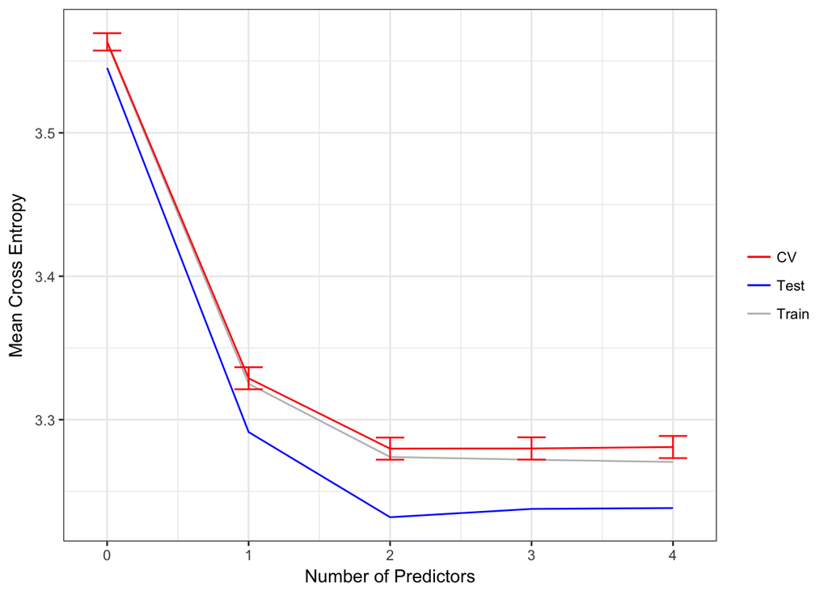

```
=======================================================
Best Model:
  dep ~ num.neg.endorsed + num.pos.endorsed

Deviance Residuals:
    Min       1Q   Median       3Q      Max
-3.6444  -0.7255  -0.0523   0.4610   2.2455

Coefficients:
                  Estimate Std. Error z value Pr(>|z|)
(Intercept)       2.793786   0.096221  29.035  < 2e-16 ***
num.neg.endorsed  0.054583   0.005071  10.764  < 2e-16 ***
num.pos.endorsed -0.024927   0.003752  -6.644 3.05e-11 ***
---
Signif. codes:  0 '***' 0.001 '**' 0.01 '*' 0.05 '.' 0.1 ' ' 1

(Dispersion parameter for Negative Binomial(5.7328) family taken to be 1)

Log-likelihood: -1447 on 4 Df
AIC: 2902.2

Number of Fisher Scoring iterations: 1

Train-sample R-squared = 0.42, Test-sample R-squared = 0.44
Cross-validated R-squared = 0.42, 95% CI [0.4, 0.43]
=======================================================
```

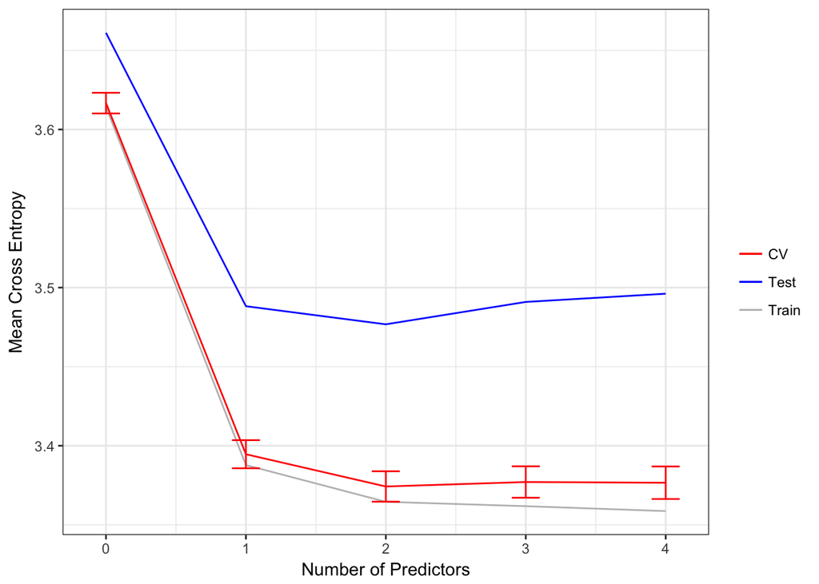

```
=======================================================
Best Model:
  dep ~ num.neg.endorsed + num.pos.endorsed

Deviance Residuals:
    Min       1Q   Median       3Q      Max
-2.6264  -0.8479  -0.1471   0.3945   2.3788

Coefficients:
                  Estimate Std. Error z value Pr(>|z|)
(Intercept)       2.590585   0.243528  10.638  < 2e-16 ***
num.neg.endorsed  0.066591   0.011303   5.891 3.83e-09 ***
num.pos.endorsed -0.028475   0.009467  -3.008  0.00263 **
---
Signif. codes:  0 '***' 0.001 '**' 0.01 '*' 0.05 '.' 0.1 ' ' 1

(Dispersion parameter for Negative Binomial(1.9496) family taken to be 1)

Log-likelihood: -760.4 on 4 Df
AIC: 1528.8

Number of Fisher Scoring iterations: 1

Train-sample R-squared = 0.36, Test-sample R-squared = 0.29
Cross-validated R-squared = 0.35, 95% CI [0.33, 0.37]
=======================================================
```

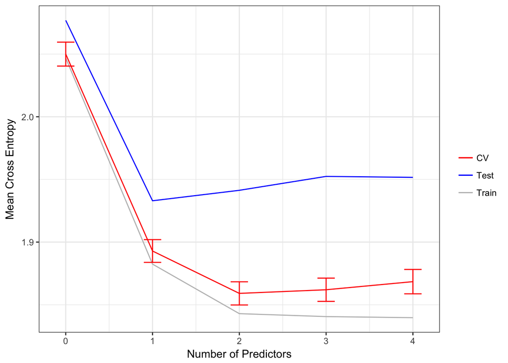

```
=======================================================
Best Model:
  dep ~ num.neg.endorsed + num.pos.endorsed

Deviance Residuals:
    Min       1Q   Median       3Q      Max
-2.3123  -1.3478  -0.3062   0.4898   2.0378

Coefficients:
                 Estimate Std. Error z value Pr(>|z|)
(Intercept)       1.43207    0.31201    4.59 4.44e-06 ***
num.neg.endorsed  0.11597    0.01787    6.49 8.57e-11 ***
num.pos.endorsed -0.05609    0.01420   -3.95 7.82e-05 ***
---
Signif. codes:  0 '***' 0.001 '**' 0.01 '*' 0.05 '.' 0.1 ' ' 1

(Dispersion parameter for Negative Binomial(1.9485) family taken to be 1)

Log-likelihood: -399.9 on 4 Df
AIC: 807.82

Number of Fisher Scoring iterations: 1

Train-sample R-squared = 0.33, Test-sample R-squared = 0.29
Cross-validated R-squared = 0.31, 95% CI [0.29, 0.33]
=======================================================
```